None

# Исследование надежности заемщиков

# Исследование надежности заёмщиков

## Введение

Данное исследование будет проведено с целью *первичного определения зависимости возвратов кредитов в срок от различных характеристик заемщиков*. Мы рассмотрим следующие характеристики:

- наличие и количество детей,
- семейное положение,
- уровень дохода,
- цели кредита.

Дополнительно, выдвинем новые гипотизы и наметим пути дальнейших исследований. Но это все во **второй части**.

А в **первой части** мы подготовим данные, которые нам были предоставлены:

- удалим прописки,
- разберемся с аномальными значениями,
- зададим правильные типы данных,
- удалим дубликаты,
- создадим нужные словари,
- и категоризируем необходимые характеристики.

И... в путь!

Во второй части проекта вы выполните шаги 3 и 4. Их вручную проверит ревьюер. Чтобы вам не пришлось писать код заново для шагов 1 и 2, мы добавили авторские решения в ячейки с кодом.

## Откройте таблицу и изучите общую информацию о данных

**Задание 1. Импортируйте библиотеку pandas. Считайте данные из csv-файла в датафрейм и сохраните в переменную `data`. Путь к файлу:**

`/datasets/data.csv`

```python
import pandas as pd
from IPython.display import display
import seaborn as sns
import matplotlib.pyplot as plt

# data = pd.read_csv('data.csv')
data = pd.read_csv('/datasets/data.csv')

# try:
#    data = pd.read_csv('/datasets/data.csv')
# except:
#    data = pd.read_csv('https://code.s3.yandex.net/datasets/data.csv')
```

**Задание 2. Выведите первые 20 строчек датафрейма `data` на экран.**

```python
data.head(20)
```

|  | children | days_employed | dob_years | education | education_id | family_status | family_status_id | gender | income_type | debt | total_income | purpose |
| --- | --- | --- | --- | --- | --- | --- | --- | --- | --- | --- | --- | --- |
| 0 | 1 | -8437.673028 | 42 | высшее | 0 | женат / замужем | 0 | F | сотрудник | 0 | 253875.639453 | покупка жилья |
| 1 | 1 | -4024.803754 | 36 | среднее | 1 | женат / замужем | 0 | F | сотрудник | 0 | 112080.014102 | приобретение автомобиля |
| 2 | 0 | -5623.422610 | 33 | Среднее | 1 | женат / замужем | 0 | M | сотрудник | 0 | 145885.952297 | покупка жилья |
| 3 | 3 | -4124.747207 | 32 | среднее | 1 | женат / замужем | 0 | M | сотрудник | 0 | 267628.550329 | дополнительное образование |
| 4 | 0 | 340266.072047 | 53 | среднее | 1 | гражданский брак | 1 | F | пенсионер | 0 | 158616.077870 | сыграть свадьбу |
| 5 | 0 | -926.185831 | 27 | высшее | 0 | гражданский брак | 1 | M | компаньон | 0 | 255763.565419 | покупка жилья |
| 6 | 0 | -2879.202052 | 43 | высшее | 0 | женат / замужем | 0 | F | компаньон | 0 | 240525.971920 | операции с жильем |
| 7 | 0 | -152.779569 | 50 | СРЕДНЕЕ | 1 | женат / замужем | 0 | M | сотрудник | 0 | 135823.934197 | образование |
| 8 | 2 | -6929.865299 | 35 | ВЫСШЕЕ | 0 | гражданский брак | 1 | F | сотрудник | 0 | 95856.832424 | на проведение свадьбы |
| 9 | 0 | -2188.756445 | 41 | среднее | 1 | женат / замужем | 0 | M | сотрудник | 0 | 144425.938277 | покупка жилья для семьи |
| 10 | 2 | -4171.483647 | 36 | высшее | 0 | женат / замужем | 0 | M | компаньон | 0 | 113943.491460 | покупка недвижимости |
| 11 | 0 | -792.701887 | 40 | среднее | 1 | женат / замужем | 0 | F | сотрудник | 0 | 77069.234271 | покупка коммерческой недвижимости |
| 12 | 0 | NaN | 65 | среднее | 1 | гражданский брак | 1 | M | пенсионер | 0 | NaN | сыграть свадьбу |
| 13 | 0 | -1846.641941 | 54 | неоконченное высшее | 2 | женат / замужем | 0 | F | сотрудник | 0 | 130458.228857 | приобретение автомобиля |
| 14 | 0 | -1844.956182 | 56 | высшее | 0 | гражданский брак | 1 | F | компаньон | 1 | 165127.911772 | покупка жилой недвижимости |
| 15 | 1 | -972.364419 | 26 | среднее | 1 | женат / замужем | 0 | F | сотрудник | 0 | 116820.904450 | строительство собственной недвижимости |
| 16 | 0 | -1719.934226 | 35 | среднее | 1 | женат / замужем | 0 | F | сотрудник | 0 | 289202.704229 | недвижимость |
| 17 | 0 | -2369.999720 | 33 | высшее | 0 | гражданский брак | 1 | M | сотрудник | 0 | 90410.586745 | строительство недвижимости |
| 18 | 0 | 400281.136913 | 53 | среднее | 1 | вдовец / вдова | 2 | F | пенсионер | 0 | 56823.777243 | на покупку подержанного автомобиля |
| 19 | 0 | -10038.818549 | 48 | СРЕДНЕЕ | 1 | в разводе | 3 | F | сотрудник | 0 | 242831.107982 | на покупку своего автомобиля |

**Задание 3. Выведите основную информацию о датафрейме с помощью метода `info()`.**

```python
data.info()
```

```
<class 'pandas.core.frame.DataFrame'>
RangeIndex: 21525 entries, 0 to 21524
Data columns (total 12 columns):
 #   Column            Non-Null Count  Dtype
---  ------            --------------  -----
 0   children          21525 non-null  int64
 1   days_employed     19351 non-null  float64
 2   dob_years         21525 non-null  int64
 3   education         21525 non-null  object
 4   education_id      21525 non-null  int64
 5   family_status     21525 non-null  object
 6   family_status_id  21525 non-null  int64
 7   gender            21525 non-null  object
 8   income_type       21525 non-null  object
 9   debt              21525 non-null  int64
 10  total_income      19351 non-null  float64
 11  purpose           21525 non-null  object
dtypes: float64(2), int64(5), object(5)
memory usage: 2.0+ MB
```

## Предобработка данных

### Удаление пропусков

**Задание 4. Выведите количество пропущенных значений для каждого столбца. Используйте комбинацию двух методов.**

```python
data.isna().sum()
```

```
children               0
days_employed       2174
dob_years              0
education              0
education_id           0
family_status          0
family_status_id       0
gender                 0
income_type            0
debt                   0
total_income        2174
purpose                0
dtype: int64
```

**Задание 5. В двух столбцах есть пропущенные значения. Один из них — `days_employed`. Пропуски в этом столбце вы обработаете на следующем этапе. Другой столбец с пропущенными значениями — `total_income` — хранит данные о доходах. На сумму дохода сильнее всего влияет тип занятости, поэтому заполнить пропуски в этом столбце нужно медианным значением по каждому типу из столбца `income_type`. Например, у человека с типом занятости `сотрудник` пропуск в столбце `total_income` должен быть заполнен медианным доходом среди всех записей с тем же типом.**

```python
for t in data['income_type'].unique():
    data.loc[(data['income_type'] == t) & (data['total_income'].isna()), 'total_income'] = \
    data.loc[(data['income_type'] == t), 'total_income'].median()
```

### Обработка аномальных значений

**Задание 6. В данных могут встречаться артефакты (аномалии) — значения, которые не отражают действительность и появились по какой-то ошибке. таким артефактом будет отрицательное количество дней трудового стажа в столбце `days_employed`. Для реальных данных это нормально. Обработайте значения в этом столбце: замените все отрицательные значения положительными с помощью метода `abs()`.**

```python
data['days_employed'] = data['days_employed'].abs()
```

**Задание 7. Для каждого типа занятости выведите медианное значение трудового стажа `days_employed` в днях.**

```python
data.groupby('income_type')['days_employed'].agg('median')
```

```
income_type
безработный        366413.652744
в декрете            3296.759962
госслужащий          2689.368353
компаньон            1547.382223
пенсионер          365213.306266
предприниматель       520.848083
сотрудник            1574.202821
студент               578.751554
Name: days_employed, dtype: float64
```

У двух типов (безработные и пенсионеры) получатся аномально большие значения. Исправить такие значения сложно, поэтому оставьте их как есть. Тем более этот столбец не понадобится вам для исследования.

**Задание 8. Выведите перечень уникальных значений столбца `children`.**

```python
data['children'].unique()
```

```
array([ 1,  0,  3,  2, -1,  4, 20,  5])
```

**Задание 9. В столбце `children` есть два аномальных значения. Удалите строки, в которых встречаются такие аномальные значения из датафрейма `data`.**

```python
data = data[(data['children'] != -1) & (data['children'] != 20)]
```

**Задание 10. Ещё раз выведите перечень уникальных значений столбца `children`, чтобы убедиться, что артефакты удалены.**

```python
data['children'].unique()
```

```
array([1, 0, 3, 2, 4, 5])
```

### Удаление пропусков (продолжение)

**Задание 11. Заполните пропуски в столбце `days_employed` медианными значениями по каждого типа занятости `income_type`.**

```python
for t in data['income_type'].unique():
    data.loc[(data['income_type'] == t) & (data['days_employed'].isna()), 'days_employed'] = \
    data.loc[(data['income_type'] == t), 'days_employed'].median()
```

**Задание 12. Убедитесь, что все пропуски заполнены. Проверьте себя и ещё раз выведите количество пропущенных значений для каждого столбца с помощью двух методов.**

```python
data.isna().sum()
```

```
children            0
days_employed       0
dob_years           0
education           0
education_id        0
family_status       0
family_status_id    0
gender              0
income_type         0
debt                0
total_income        0
purpose             0
dtype: int64
```

### Изменение типов данных

**Задание 13. Замените вещественный тип данных в столбце `total_income` на целочисленный с помощью метода `astype()`.**

```python
data['total_income'] = data['total_income'].astype(int)
```

### Обработка дубликатов

**Задание 14. Обработайте неявные дубликаты в столбце `education`. В этом столбце есть одни и те же значения, но записанные по-разному: с использованием заглавных и строчных букв. Приведите их к нижнему регистру. Проверьте остальные столбцы.**

```python
data['education'] = data['education'].str.lower()
```

**Задание 15. Выведите на экран количество строк-дубликатов в данных. Если такие строки присутствуют, удалите их.**

```python
data.duplicated().sum()
```

```
71
```

```python
data = data.drop_duplicates()
```

### Категоризация данных

**Задание 16. На основании диапазонов, указанных ниже, создайте в датафрейме `data` столбец `total_income_category` с категориями:**

- 0–30000 — `'E'`;
- 30001–50000 — `'D'`;
- 50001–200000 — `'C'`;
- 200001–1000000 — `'B'`;
- 1000001 и выше — `'A'`.

**Например, кредитополучателю с доходом 25000 нужно назначить категорию `'E'`, а клиенту, получающему 235000, — `'B'`. Используйте собственную функцию с именем `categorize_income()` и метод `apply()`.**

```python
def categorize_income(income):
    try:
        if 0 <= income <= 30000:
            return 'E'
        elif 30001 <= income <= 50000:
            return 'D'
        elif 50001 <= income <= 200000:
            return 'C'
        elif 200001 <= income <= 1000000:
            return 'B'
        elif income >= 1000001:
            return 'A'
    except:
        pass
```

```python
data['total_income_category'] = data['total_income'].apply(categorize_income)
```

**Задание 17. Выведите на экран перечень уникальных целей взятия кредита из столбца `purpose`.**

```python
data['purpose'].unique()
```

```
array(['покупка жилья', 'приобретение автомобиля',
       'дополнительное образование', 'сыграть свадьбу',
       'операции с жильем', 'образование', 'на проведение свадьбы',
       'покупка жилья для семьи', 'покупка недвижимости',
       'покупка коммерческой недвижимости', 'покупка жилой недвижимости',
       'строительство собственной недвижимости', 'недвижимость',
       'строительство недвижимости', 'на покупку подержанного автомобиля',
       'на покупку своего автомобиля',
       'операции с коммерческой недвижимостью',
       'строительство жилой недвижимости', 'жилье',
       'операции со своей недвижимостью', 'автомобили',
       'заняться образованием', 'сделка с подержанным автомобилем',
       'получение образования', 'автомобиль', 'свадьба',
       'получение дополнительного образования', 'покупка своего жилья',
       'операции с недвижимостью', 'получение высшего образования',
       'свой автомобиль', 'сделка с автомобилем',
       'профильное образование', 'высшее образование',
       'покупка жилья для сдачи', 'на покупку автомобиля', 'ремонт жилью',
       'заняться высшим образованием'], dtype=object)
```

**Задание 18. Создайте функцию, которая на основании данных из столбца `purpose` сформирует новый столбец `purpose_category`, в который войдут следующие категории:**

- `'операции с автомобилем'`,
- `'операции с недвижимостью'`,
- `'проведение свадьбы'`,
- `'получение образования'`.

**Например, если в столбце `purpose` находится подстрока `'на покупку автомобиля'`, то в столбце `purpose_category` должна появиться строка `'операции с автомобилем'`.**

**Используйте собственную функцию с именем `categorize_purpose()` и метод `apply()`. Изучите данные в столбце `purpose` и определите, какие подстроки помогут вам правильно определить категорию.**

```python
def categorize_purpose(row):
    try:
        if 'автом' in row:
            return 'операции с автомобилем'
        elif 'жил' in row or 'недвиж' in row:
            return 'операции с недвижимостью'
        elif 'свад' in row:
            return 'проведение свадьбы'
        elif 'образов' in row:
            return 'получение образования'
    except:
        return 'нет категории'
```

```python
data['purpose_category'] = data['purpose'].apply(categorize_purpose)
```

### Шаг 3. Исследуйте данные и ответьте на вопросы

#### 3.1 Есть ли зависимость между количеством детей и возвратом кредита в срок?

Из описания проекта становится понятно, что за количество детей отвечает столбец `children`, а за возврат кредита столбец `debt`. Проверим столбец `debt` на заполненность и уникальность значений. Столбец `children` был проверен ранее.

```python
# Ваш код будет здесь. Вы можете создавать новые ячейки.
display(data['debt'].isna().sum())
data['debt'].unique()
```

```
0
```

```
array([0, 1])
```

Столбцы `children` и `debt` не содержат пропусков и содержат корректные значения. Посмотрим сколько задолженностей по возврату кредитов у семей с разным количеством детей.

```python
data.groupby('children')['debt'].sum()
```

```
children
0    1063
1     444
2     194
3      27
4       4
5       0
Name: debt, dtype: int64
```

В абсолютных значениях, конечно ситуация выглядит так, что можно подумать, что дети подталкивают отдавать кредиты вовремя. Дополнительно заметим, что 1 в столбце `debt` означает наличие задолженности, иначе некому было бы давать это задание...

Но давай проверим сколько всего кредитов берут семьи с разным количеством детей.

```python
data.groupby('children')['debt'].count()
```

```
children
0    14091
1     4808
2     2052
3      330
4       41
5        9
Name: debt, dtype: int64
```

Становится понятно, что чем больше детей, тем меньше семьи готовы или могут брать кредиты, а вот долю возврата кредита нужно посчитать внимательно. И отсортировать по возрастанию.

```python
data_children_debt= data.groupby('children').agg({'debt':['count', 'sum']})
data_children_debt['ratio'] = data_children_debt['debt']['sum'] / data_children_debt['debt']['count']
display(data_children_debt)
data_children_debt.sort_values(by='ratio')
```

| children | debt count | debt sum | ratio |
| --- | --- | --- | --- |
| 0 | 14091 | 1063 | 0.075438 |
| 1 | 4808 | 444 | 0.092346 |
| 2 | 2052 | 194 | 0.094542 |
| 3 | 330 | 27 | 0.081818 |
| 4 | 41 | 4 | 0.097561 |
| 5 | 9 | 0 | 0.000000 |

| children | debt count | debt sum | ratio |
| --- | --- | --- | --- |
| 5 | 9 | 0 | 0.000000 |
| 0 | 14091 | 1063 | 0.075438 |
| 3 | 330 | 27 | 0.081818 |
| 1 | 4808 | 444 | 0.092346 |
| 2 | 2052 | 194 | 0.094542 |
| 4 | 41 | 4 | 0.097561 |

Оказалось, доля кредитов с задолженностями среди семей с детьми выше, чем у заемщиков без детей. А вдруг дети не виноваты?

**Вывод:**

При анализе данных выяснилось, что **зависимость между количеством детей и возвратом кредитов в срок сущестует: семьи с детьми возращали кредиты до 2,3% хуже** чем заёмщики без детей. Но **важно отметить, что и количество заемщиков с детьми падает в геометрической прогрессии с увеличением детей** из-за чего данные для семей с 3 и более детьми можно поставить под сомнение с точки зрения статистики.

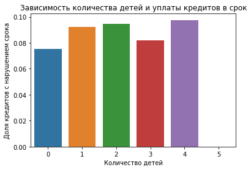

```python
sns.barplot(
    x="children",
    y="debt",
    ci=None,
    data=data
)
plt.xlabel('Количество детей')
plt.ylabel('Доля кредитов с нарушением срока')
plt.title("Зависимость количества детей и уплаты кредитов в срок")
plt.show()
```

#### 3.2 Есть ли зависимость между семейным положением и возвратом кредита в срок?

```python
# Ваш код будет здесь. Вы можете создавать новые ячейки.
data.head(5)
```

|  | children | days_employed | dob_years | education | education_id | family_status | family_status_id | gender | income_type | debt | total_income | purpose | total_income_category | purpose_category |
| --- | --- | --- | --- | --- | --- | --- | --- | --- | --- | --- | --- | --- | --- | --- |
| 0 | 1 | 8437.673028 | 42 | высшее | 0 | женат / замужем | 0 | F | сотрудник | 0 | 253875 | покупка жилья | B | операции с недвижимостью |
| 1 | 1 | 4024.803754 | 36 | среднее | 1 | женат / замужем | 0 | F | сотрудник | 0 | 112080 | приобретение автомобиля | C | операции с автомобилем |
| 2 | 0 | 5623.422610 | 33 | среднее | 1 | женат / замужем | 0 | M | сотрудник | 0 | 145885 | покупка жилья | C | операции с недвижимостью |
| 3 | 3 | 4124.747207 | 32 | среднее | 1 | женат / замужем | 0 | M | сотрудник | 0 | 267628 | дополнительное образование | B | получение образования |
| 4 | 0 | 340266.072047 | 53 | среднее | 1 | гражданский брак | 1 | F | пенсионер | 0 | 158616 | сыграть свадьбу | C | проведение свадьбы |

Из информации выше видно, что семейное положение отражено с столбцах `family_status` и `family_status_id`, а возврат кредита в столбце `debt`. Хорошо, что пропусков у нас в этих столбцах нет, и с типами данных тоже все хорошо.

1 в столбце `debt` показывает, что есть задолженность по кредиту, а вот семейным положением нужно разобраться.

```python
# data.groupby('family_status')['family_status_id'].unique()
data.groupby('family_status')['family_status_id'].value_counts()
```

```
family_status          family_status_id
Не женат / не замужем  4                    2796
в разводе              3                    1189
вдовец / вдова         2                     951
гражданский брак       1                    4134
женат / замужем        0                   12261
Name: family_status_id, dtype: int64
```

Соотношение значений в столбцах `family_status` и `family_status_id` правильное. Мы можем работать с любым их этих столбцов.

Начнем исследование: Найдем доли возвратов вовремя кредитов для разных семейных статусов.

```python
data_family_debt = data.pivot_table(index='family_status', values='debt', aggfunc=[ 'sum', 'count'])
data_family_debt['ratio'] = data_family_debt['sum']['debt'] / data_family_debt['count']['debt']
data_family_debt
```

| family_status | sum debt | count debt | ratio |
| --- | --- | --- | --- |
| Не женат / не замужем | 273 | 2796 | 0.097639 |
| в разводе | 84 | 1189 | 0.070648 |
| вдовец / вдова | 63 | 951 | 0.066246 |
| гражданский брак | 385 | 4134 | 0.093130 |
| женат / замужем | 927 | 12261 | 0.075606 |

Отсортируем.

```python
data_family_debt.sort_values(by='ratio')
```

| family_status | sum debt | count debt | ratio |
| --- | --- | --- | --- |
| вдовец / вдова | 63 | 951 | 0.066246 |
| в разводе | 84 | 1189 | 0.070648 |
| женат / замужем | 927 | 12261 | 0.075606 |
| гражданский брак | 385 | 4134 | 0.093130 |
| Не женат / не замужем | 273 | 2796 | 0.097639 |

**Вывод:**

**Зависимость между семейным положением и возвратом кредита в срок существует**. Она выражена в том, что люди официально оформившие брак возвращают кредиты в срок лучше. Из таблицы выше видим, что у категорий *гражданский брак* и *Не женат / не замужем* доля возврата кредитов в срок хуже на 1,7% и более по сравнению с другими категориями.

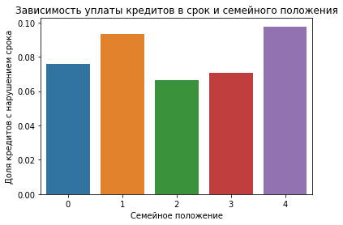

```python
sns.barplot(
    x='family_status_id',
    y="debt",
    ci=None,
    data=data,
   )
plt.xlabel('Семейное положение')
plt.ylabel('Доля кредитов с нарушением срока')
plt.title("Зависимость уплаты кредитов в срок и семейного положения")
plt.show()
```

#### 3.3 Есть ли зависимость между уровнем дохода и возвратом кредита в срок?

В Задании 16 мы уже сделали категоризацию доходов.

- 0–30000 — `'E'`;
- 30001–50000 — `'D'`;
- 50001–200000 — `'C'`;
- 200001–1000000 — `'B'`;
- 1000001 и выше — `'A'`.

Она отражена в столбце `total_income_category`.

Возврат кредита в срок опраделяется в столбце `debt`, где 1 означает, задолженность существует.

Пропусков в обоих столбцах нет. Поэтому перейдем к анализу.

```python
data_income_debt = data.pivot_table(index='total_income_category', values='debt', aggfunc=[ 'sum', 'count'])
data_income_debt['ratio'] = data_income_debt['sum']['debt'] / data_income_debt['count']['debt']
data_income_debt
```

| total_income_category | sum debt | count debt | ratio |
| --- | --- | --- | --- |
| A | 2 | 25 | 0.080000 |
| B | 354 | 5014 | 0.070602 |
| C | 1353 | 15921 | 0.084982 |
| D | 21 | 349 | 0.060172 |
| E | 2 | 22 | 0.090909 |

Отсортируем.

```python
data_income_debt.sort_values(by='ratio')
```

| total_income_category | sum debt | count debt | ratio |
| --- | --- | --- | --- |
| D | 21 | 349 | 0.060172 |
| B | 354 | 5014 | 0.070602 |
| A | 2 | 25 | 0.080000 |
| C | 1353 | 15921 | 0.084982 |
| E | 2 | 22 | 0.090909 |

```python
data_income_debt['ratio'].mean()  # среднее
```

```
0.07733308466327596
```

```python
data_income_debt['ratio'].median() # медиана
```

```
0.08
```

Количество кредитов для категорий А, Е и D очень мало и трудно их оценивать. Но можно отметить, что при доходах меньше 30000 (категория E), трудно обслуживать кредиты, что подтверждается высокой долей не возврата.

Для остальных же категорий разброс долей не значительный (менее 1% от средней и медианы) и может быть связан больше с разницей количества выданных кредитов. Поэтому выводы сделаем относительно каждой категории.

**Вывод:**

**Системной зависимости уровня дохода и возвратом кредита в срок не обнаружено**, но возможно сделать выводы для каждой из категорий:

- Чаще всего кредиты выдаются категориям **C** и **B** (доходы от 50001 до 1000000).
- Категория **C** с доходом от 500001 до 200000 имеет долю кредитов с нарушением сроков платежей не многим выше среднего, а категория **B** вторая по значимости не многим ниже среднего.
- При доходах меньше 30000 (категория **E**), трудно обслуживать кредиты, что подтверждается высокой долей не возврата.
- Категория **D** редко пользуется кредитами, но доля задержек выплат по кредитам очень низкая.
- Категория **A** требует индивидуального подхода.

#### 3.4 Как разные цели кредита влияют на его возврат в срок?

В Задании 18 уже сделана категоризация целей кредита: столбец `purpose_category`. Проверим данные.

```python
data['purpose_category'].value_counts() # проверим значения
```

```
операции с недвижимостью    10751
операции с автомобилем       4279
получение образования        3988
проведение свадьбы           2313
Name: purpose_category, dtype: int64
```

```python
data['purpose_category'].isna().sum() # проверим на пропуски данных
```

```
0
```

Возврат кредита в срок опраделяется в столбце `debt`, где 1 означает, задолженность существует.

Пропусков в обоих столбцах нет. Поэтому перейдем к анализу. Найдем долю просроченных кредитов по каждой категории целей кредита.

```python
data_purpose_debt = data.pivot_table(index='purpose_category', values='debt', aggfunc=[ 'sum', 'count'])
data_purpose_debt['ratio'] = data_purpose_debt['sum']['debt'] / data_purpose_debt['count']['debt']
data_purpose_debt
```

| purpose_category | sum debt | count debt | ratio |
| --- | --- | --- | --- |
| операции с автомобилем | 400 | 4279 | 0.093480 |
| операции с недвижимостью | 780 | 10751 | 0.072551 |
| получение образования | 369 | 3988 | 0.092528 |
| проведение свадьбы | 183 | 2313 | 0.079118 |

Отсортируем.

```python
data_purpose_debt.sort_values(by='ratio')
```

| purpose_category | sum debt | count debt | ratio |
| --- | --- | --- | --- |
| операции с недвижимостью | 780 | 10751 | 0.072551 |
| проведение свадьбы | 183 | 2313 | 0.079118 |
| получение образования | 369 | 3988 | 0.092528 |
| операции с автомобилем | 400 | 4279 | 0.093480 |

**Вывод:**

**Влияние целей взятия кредитов на его возврат в срок существует.** Из таблицы видно, наши категории разбились на 2 пары:

- *операции с недвижимостью* и *проведение свадьбы* с долей до 8%,
- *получение образования* и *операции с автомобилем* с долей выше 9%.

При этом *операции с недвижимостью* занимают подавляющую долю кредитов и имеют самую низкую долю кредитов с задержками платежей. Это очень хорошо. А вот на категориям *операции с автомобилем* и *получение образования* нужно уделить пристальное внимание.

**Можно выдвинуть дополнительные гипотезы:**

- низкая доля кредитов с задержками платежей в категории *операции с недвижимостью* связана с тем, что залогом является недвижимость и большое количество таких кредитов берут женатые люди: 2 залогодателя,
- низкая доля кредитов с задержками платежей в категории *проведение свадьбы* связана с тем, что плательщиков кредита становиться двое,
- высокая доля кредитов с задержками платежей в категории *получение образования* связано с возрастом до 25 лет и типом и как следстивие размером дохода,
- высокая доля кредитов с задержками платежей в категории *операции с автомобилями* связана с величиной доходов и неприятностями с автомобилями (аварии, кражи и т.д.).

**Дополнительно** проверим одну из гипотез, для которой у нас хватает данных.

**Гипотеза**: низкая доля кредитов с задержками платежей в категории *операции с недвижимостью* связана с тем, большое количество таких кредитов берут женатые люди: 2 залогодателя.

```python
# возьмем данные только по операциям с недвижимостью
data_purpose_family_debt = data.loc[(data['purpose_category'] == 'операции с недвижимостью')]
# определимся с ситацией с редитами по семейному статусу
data_purpose_family_debt_groupped = data_purpose_family_debt.groupby('family_status').agg({'debt':['count', 'sum']})
# опредилим долю кредитов с задержкой платежей
data_purpose_family_debt_groupped['ratio_debt'] = data_purpose_family_debt_groupped['debt']['sum'] / data_purpose_family_debt_groupped['debt']['count']
# определим долю кредитов на недвижимость по семейному статусу
total_credits_estate = sum(data_purpose_family_debt_groupped['debt']['count'])
data_purpose_family_debt_groupped['ratio_credits_estate'] = data_purpose_family_debt_groupped['debt']['count'] / total_credits_estate
display(data_purpose_family_debt_groupped)
data_purpose_family_debt_groupped.sort_values(by='ratio_credits_estate') # отсортируем
```

| family_status | debt count | debt sum | ratio_debt | ratio_credits_estate |
| --- | --- | --- | --- | --- |
| Не женат / не замужем | 1586 | 129 | 0.081337 | 0.147521 |
| в разводе | 672 | 46 | 0.068452 | 0.062506 |
| вдовец / вдова | 535 | 28 | 0.052336 | 0.049763 |
| гражданский брак | 988 | 91 | 0.092105 | 0.091898 |
| женат / замужем | 6970 | 486 | 0.069727 | 0.648312 |

| family_status | debt count | debt sum | ratio_debt | ratio_credits_estate |
| --- | --- | --- | --- | --- |
| вдовец / вдова | 535 | 28 | 0.052336 | 0.049763 |
| в разводе | 672 | 46 | 0.068452 | 0.062506 |
| гражданский брак | 988 | 91 | 0.092105 | 0.091898 |
| Не женат / не замужем | 1586 | 129 | 0.081337 | 0.147521 |
| женат / замужем | 6970 | 486 | 0.069727 | 0.648312 |

**Вывод:** Как мы видим из таблицы более 64% кредитов на недвижимость берут женатые люди и доля кредитов с задержкой платежей у них низкая. Наша гипотеза подтвердилась.

#### 3.5 Приведите возможные причины появления пропусков в исходных данных.

*Ответ:* Пропуски в исходных данных:

- **человеческий фактор**
  - плохо стоставленные инструкции
  - плохо изученые инструкции
  - неумение оператора
  - нежелание оператора
  - умышленное вредительство
  - другие
- **технологические причины**
  - при копировании
  - при считывании
  - при смене формата
  - при записи данных
  - другие

#### 3.6 Объясните, почему заполнить пропуски медианным значением — лучшее решение для количественных переменных.

*Ответ:* Медина лучшее решение для заполнения пропусков количественных переменных, так как медиана меньше подвержена влиянию сильных отклонений значений, а при большом количестве данных приближается к среднему значению.

### Шаг 4: общий вывод.

В данном исследовании мы провели анализ надежности заемщиков на основании предоставленных данных. Перед началом анализа данные были подготовлены: обработаны пропуски, дубликаты и не корректные значения. В ходе исследования были проверены гипотезы и получены следующие выводы и рекомендации:

**Гипотеза 1**. Есть ли зависимость между количеством детей и возвратом кредита в срок?

**Выводы**. При анализе данных выяснилось, что **зависимость между количеством детей и возвратом кредитов в срок существует: семьи с детьми возвращали кредиты до 2,3% хуже** чем заёмщики без детей. Но **важно отметить, что и количество заемщиков с детьми падает в геометрической прогрессии с увеличением детей** из-за чего данные для семей с 3 и более детьми можно поставить под сомнение с точки зрения статистики.

**Гипотез 2**. Есть ли зависимость между семейным положением и возвратом кредита в срок?

**Выводы**. **Зависимость между семейным положением и возвратом кредита в срок существует**. Она выражена в том, что люди официально оформившие брак, в том числе разведенные и вдовствующие, возвращают кредиты в срок лучше. У категорий *гражданский брак* и *Не женат / не замужем* доля возврата кредитов в срок хуже на 1,7% и более по сравнению с другими категориями.

**Гипотеза 3**. Есть зависимость между уровнем дохода и возвратом кредита в срок?

**Выводы**. **Системной зависимости уровня дохода и возвратом кредита в срок не обнаружено**, но возможно сделать выводы для каждой из категорий:

- Чаще всего кредиты выдаются категориям **C** и **B** (доходы от 50001 до 1000000).
- Категория **C** с доходом от 500001 до 200000 имеет долю кредитов с нарушением сроков платежей не многим выше среднего, а категория **B** вторая по значимости не многим ниже среднего.
- При доходах меньше 30000 (категория **E**), трудно обслуживать кредиты, что подтверждается высокой долей не возврата.
- Категория **D** редко пользуется кредитами, но доля задержек выплат по кредитам очень низкая.
- Категория **A** требует индивидуального подхода.

**Гипотеза 4**. Как разные цели кредита влияют на возврат кредита в срок?

**Выводы**. **Влияние целей взятия кредитов на его возврат в срок существует.** Из таблицы видно, наши категории разбились на 2 пары:

- *операции с недвижимостью* и *проведение свадьбы* с долей до 8%,
- *получение образования* и *операции с автомобилем* с долей выше 9%.

При этом *операции с недвижимостью* занимают подавляющую долю кредитов и имеют самую низкую долю кредитов с задержками платежей. Это очень хорошо. А вот на категориям *операции с автомобилем* и *получение образования* нужно уделить пристальное внимание.

**В ходе работы были предложены дополнительные гипотезы:**

- низкая доля кредитов с задержками платежей в категории *операции с недвижимостью* связана с тем, что залогом является недвижимость и большое количество таких кредитов берут женатые люди: 2 залогодателя,
- низкая доля кредитов с задержками платежей в категории *проведение свадьбы* связана с тем, что плательщиков кредита становиться двое,
- высокая доля кредитов с задержками платежей в категории *получение образования* связано с возрастом до 25 лет и типом и как следствие размером дохода,
- высокая доля кредитов с задержками платежей в категории *операции с автомобилями* связана с величиной доходов и неприятностями с автомобилями (аварии, кражи и т.д.).

## Шаг 5. Разницы в заданиях в конспекте и в тетради.

### Выполнение Шаг 2, п. 5

**Задание**: Создайте два новых датафрейма со столбцами:

- `education_id` и `education` — в первом;

`family_status_id` и `family_status` — во втором.

- Удалите из исходного датафрейма столбцы `education` и `family_status`, оставив только их идентификаторы: `education_id` и `family_status_id`.

Новые датафреймы — это те самые «словари» (не путайте с одноимённой структурой данных в Python), к которым вы сможете обращаться по идентификатору.

```python
# создаем словарь education_dict
education_dict = data[['education_id', 'education']]
education_dict = education_dict.drop_duplicates().reset_index(drop=True)
education_dict
```

|  | education_id | education |
| --- | --- | --- |
| 0 | 0 | высшее |
| 1 | 1 | среднее |
| 2 | 2 | неоконченное высшее |
| 3 | 3 | начальное |
| 4 | 4 | ученая степень |

```python
# создаем словарь family_status_dict
family_status_dict = data[['family_status_id', 'family_status']]
family_status_dict = family_status_dict.drop_duplicates().reset_index(drop=True)
family_status_dict
```

|  | family_status_id | family_status |
| --- | --- | --- |
| 0 | 0 | женат / замужем |
| 1 | 1 | гражданский брак |
| 2 | 2 | вдовец / вдова |
| 3 | 3 | в разводе |
| 4 | 4 | Не женат / не замужем |

```python
# удаляем столбцы 'education', 'family_status' из data
data = data.drop(columns=['education', 'family_status'], inplace=False, errors='raise')
data.info()
```

```
<class 'pandas.core.frame.DataFrame'>
Int64Index: 21331 entries, 0 to 21524
Data columns (total 12 columns):
 #   Column                 Non-Null Count  Dtype
---  ------                 --------------  -----
 0   children               21331 non-null  int64
 1   days_employed          21331 non-null  float64
 2   dob_years              21331 non-null  int64
 3   education_id           21331 non-null  int64
 4   family_status_id       21331 non-null  int64
 5   gender                 21331 non-null  object
 6   income_type            21331 non-null  object
 7   debt                   21331 non-null  int64
 8   total_income           21331 non-null  int64
 9   purpose                21331 non-null  object
 10  total_income_category  21331 non-null  object
 11  purpose_category       21331 non-null  object
dtypes: float64(1), int64(6), object(5)
memory usage: 2.6+ MB
```